# Lab 4

Leslie Ransehousen

2025-02-05

# Part A: Mapping Tornado Density: A Spatial Analysis of Oklahoma (2016-2021)

## Introduction

Tornado are one of the most destructive forces in nature, causing signficant damage to property, infrastructure, and lives. Understanding their spatial patterns can assist researchers, policymakers, and emergency management teams make more informed decisions and prepare for future touchdowns. This report analyzes tornado activity in Oklahoma from 2016 to 2021, focusing on tornado paths, touchdown points, and densisty patterns. The analysis is composed of three portions:

1. **Tornado Paths and Points-** Points representing individual tornado occurrences while paths depict the trajectory the tornado as it moves across the landscape. Each year is color-coded to identify patterns and highlight recurring activity.
2. **Tornado Density by County and Year-** Tornado density is summarized at the county level for each year from 2016-2021, Through aggregating the tornado data to counties researchers gain insight into spatial variations in tornado frequency within Oklahoma. Each panel of the faceted map represents tornado density per year allowing for year over year analysis of trends and hotspots.
3. **Choropleth Maps of Tornado Density-** These maps depict tornado density broken into county classifications. These maps are combined into a single composite figure allowing for side by side comparisons revealing patterns in tornado density across Oklahoma.

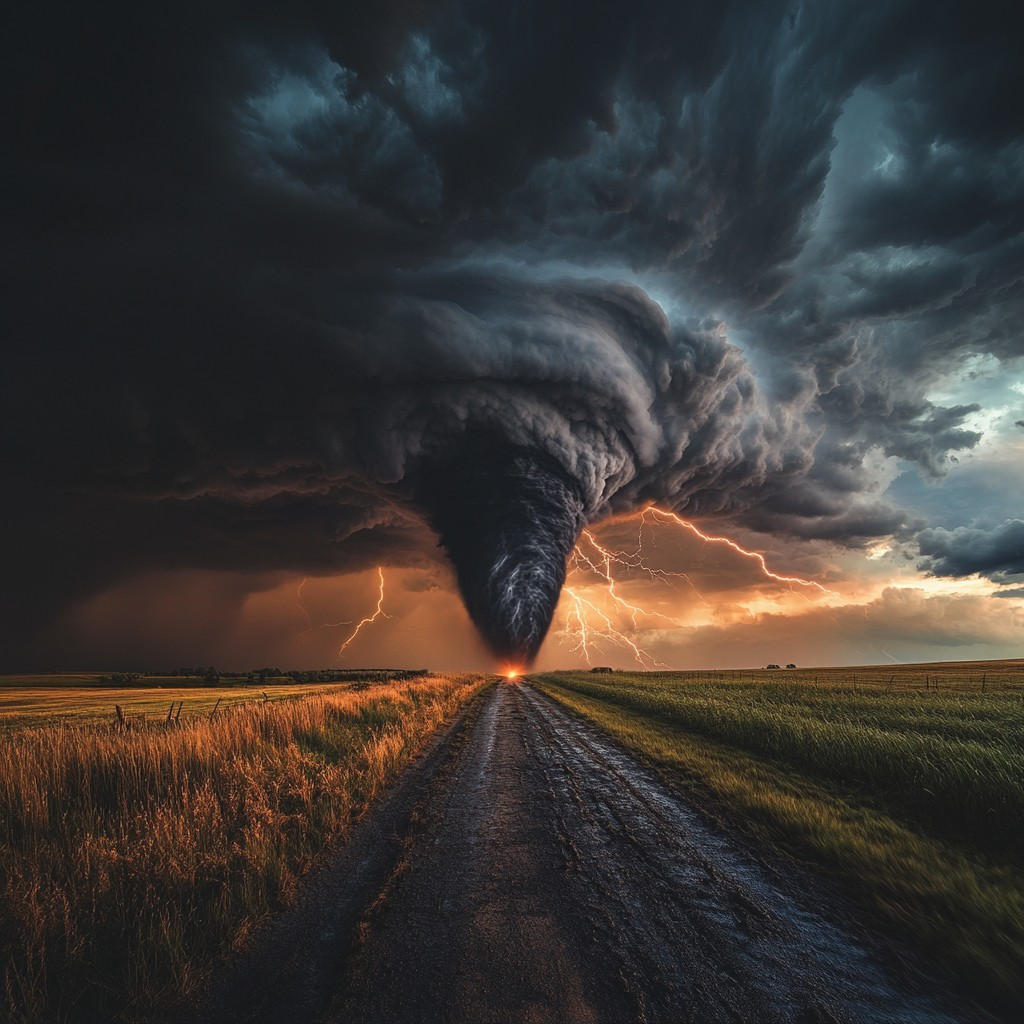